# lab3

Steve Newns

May 21, 2018

## Pitcher prediction using the Lahman database for

- Gain more experience w/ `Lahman` package, while also learning model comparison tools using multivariate regression.
- Apply tools to derive predictions of pitcher performance.

```r
library(Lahman)
library(mosaic)
library(ggplot2)
library(tidyverse)


data(Teams)
head(Teams)
```

```
##   yearID lgID teamID franchID divID Rank  G Ghome  W  L DivWin WCWin LgWin
## 1   1871   NA    BS1      BNA  <NA>    3 31    NA 20 10   <NA>  <NA>     N
## 2   1871   NA    CH1      CNA  <NA>    2 28    NA 19  9   <NA>  <NA>     N
## 3   1871   NA    CL1      CFC  <NA>    8 29    NA 10 19   <NA>  <NA>     N
## 4   1871   NA    FW1      KEK  <NA>    7 19    NA  7 12   <NA>  <NA>     N
## 5   1871   NA    NY2      NNA  <NA>    5 33    NA 16 17   <NA>  <NA>     N
## 6   1871   NA    PH1      PNA  <NA>    1 28    NA 21  7   <NA>  <NA>     Y
##   WSWin   R   AB   H X2B X3B HR BB SO SB CS HBP SF  RA  ER  ERA CG SHO SV
## 1  <NA> 401 1372 426  70  37  3 60 19 73 NA  NA NA 303 109 3.55 22   1  3
## 2  <NA> 302 1196 323  52  21 10 60 22 69 NA  NA NA 241  77 2.76 25   0  1
## 3  <NA> 249 1186 328  35  40  7 26 25 18 NA  NA NA 341 116 4.11 23   0  0
## 4  <NA> 137  746 178  19   8  2 33  9 16 NA  NA NA 243  97 5.17 19   1  0
## 5  <NA> 302 1404 403  43  21  1 33 15 46 NA  NA NA 313 121 3.72 32   1  0
## 6  <NA> 376 1281 410  66  27  9 46 23 56 NA  NA NA 266 137 4.95 27   0  0
##   IPouts  HA HRA BBA SOA   E DP    FP                    name
```

[output cut: 20 more lines]

```r
tail(Teams)
```

```
##      yearID lgID teamID franchID divID Rank   G Ghome  W  L DivWin WCWin
## 2830   2016   NL    SFN      SFG     W    2 162    81 87 75      N     Y
## 2831   2016   NL    SLN      STL     C    2 162    81 86 76      N     N
## 2832   2016   AL    TBA      TBD     E    5 162    81 68 94      N     N
## 2833   2016   AL    TEX      TEX     W    1 162    81 95 67      Y     N
## 2834   2016   AL    TOR      TOR     E    2 162    81 89 73      N     Y
## 2835   2016   NL    WAS      WSN     E    1 162    81 95 67      Y     N
##      LgWin WSWin   R   AB    H X2B X3B  HR  BB   SO  SB CS HBP SF  RA  ER
## 2830     N     N 715 5565 1437 280  54 130 572 1107  79 36  42 46 631 593
## 2831     N     N 779 5548 1415 299  32 225 526 1318  35 26  70 41 712 656
## 2832     N     N 672 5481 1333 288  32 216 449 1482  60 37  69 28 713 665
## 2833     N     N 765 5525 1446 257  23 215 436 1220  99 36  70 40 757 700
## 2834     N     N 759 5479 1358 276  18 221 632 1362  54 24  55 40 666 613
## 2835     N     N 763 5490 1403 268  29 203 536 1252 121 39  64 63 612 570
##       ERA CG SHO SV IPouts   HA HRA BBA  SOA   E  DP    FP
```

[output cut: 20 more lines]

```r
teams_1 <- Teams %>% filter(yearID >= 1970)
head(teams_1)
```

```
##   yearID lgID teamID franchID divID Rank   G Ghome   W   L DivWin WCWin
## 1   1970   NL    ATL      ATL     W    5 162    81  76  86      N  <NA>
## 2   1970   AL    BAL      BAL     E    1 162    81 108  54      Y  <NA>
## 3   1970   AL    BOS      BOS     E    3 162    81  87  75      N  <NA>
## 4   1970   AL    CAL      ANA     W    3 162    81  86  76      N  <NA>
## 5   1970   AL    CHA      CHW     W    6 162    84  56 106      N  <NA>
## 6   1970   NL    CHN      CHC     E    2 162    80  84  78      N  <NA>
##   LgWin WSWin   R   AB    H X2B X3B  HR  BB  SO SB CS HBP SF  RA  ER  ERA
## 1     N     N 736 5546 1495 215  24 160 522 736 58 34  NA NA 772 688 4.33
## 2     Y     Y 792 5545 1424 213  25 179 717 952 84 39  NA NA 574 517 3.15
## 3     N     N 786 5535 1450 252  28 203 594 855 50 48  NA NA 722 622 3.87
## 4     N     N 631 5532 1391 197  40 114 447 922 69 27  NA NA 630 565 3.48
## 5     N     N 633 5514 1394 192  20 123 477 872 53 33  NA NA 822 721 4.54
## 6     N     N 806 5491 1424 228  44 179 607 844 39 16  NA NA 679 600 3.76
##   CG SHO SV IPouts   HA HRA BBA  SOA   E  DP    FP              name
```

[output cut: 20 more lines]

### Comparing multiple regression models.

Old saying in statistics, attributed to George Box: *all models are wrong, some are useful*. In practice, we *never* know if a regression model is correctly specified; e.g, that it *truly* is the case that $y$, $x_1$, … and $x_{p???1}$ are linearly related. All we can do is hope, + try a few analytical tools.

Try to come up with a few models of `RA`, 1st via a recap of multiple regression.

```r
fit_1 <- lm(RA ~ HRA + BBA + SOA + HA, teams_1)
#summary(fit_1)
msummary(fit_1) # less unnecessary output
```

```
##               Estimate Std. Error t value Pr(>|t|)
## (Intercept) -1.544e+02  1.136e+01  -13.59   <2e-16 ***
## HRA          1.249e+00  3.458e-02   36.11   <2e-16 ***
## BBA          3.605e-01  1.381e-02   26.11   <2e-16 ***
## SOA         -7.275e-02  5.295e-03  -13.74   <2e-16 ***
## HA           3.982e-01  9.371e-03   42.49   <2e-16 ***
##
## Residual standard error: 31.98 on 1289 degrees of freedom
## Multiple R-squared:  0.8993, Adjusted R-squared:  0.899
## F-statistic:  2879 on 4 and 1289 DF,  p-value: < 2.2e-16
```

**1. Write the estimated model above.**

- $RA = -154 + 1.249HRA + .3605BBA - .07275SOA + .3982HA$

**2. Using the model in question (1), interpret the coefficient on HRA.**

**3. Note that this coefficient estimate is noticeably different than the one found on the identical data in Lecture 3 ($\beta_1 = 2.00$). Can you explain the difference?**

- Other factors have some interaction with `HRA`, resulting in a different effect magnitude of `HRA`

After fitting a linear regression model, it is appropriate to **check assumptions**. 1st, check the appropriateness of the normal distribution for residuals.

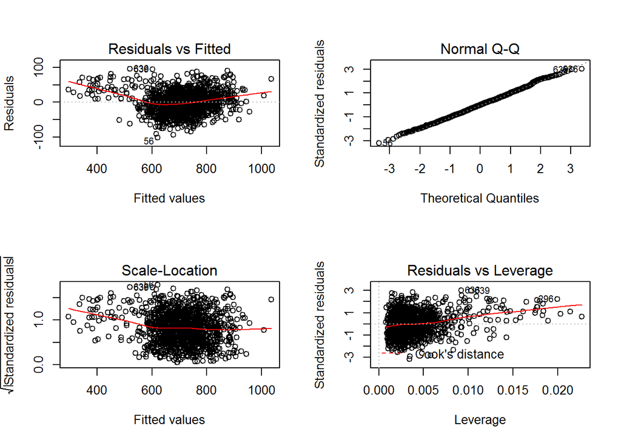

```r
par(mfrow=c(2,2))
plot(fit_1)
```

- See a mild U-shape in the residuals, with some high leverage points in the Residuals vs. Leverage Plot. But, the main cloud/cluster in the Residuals plot seems random

Get a closer look at the Q-Q plot

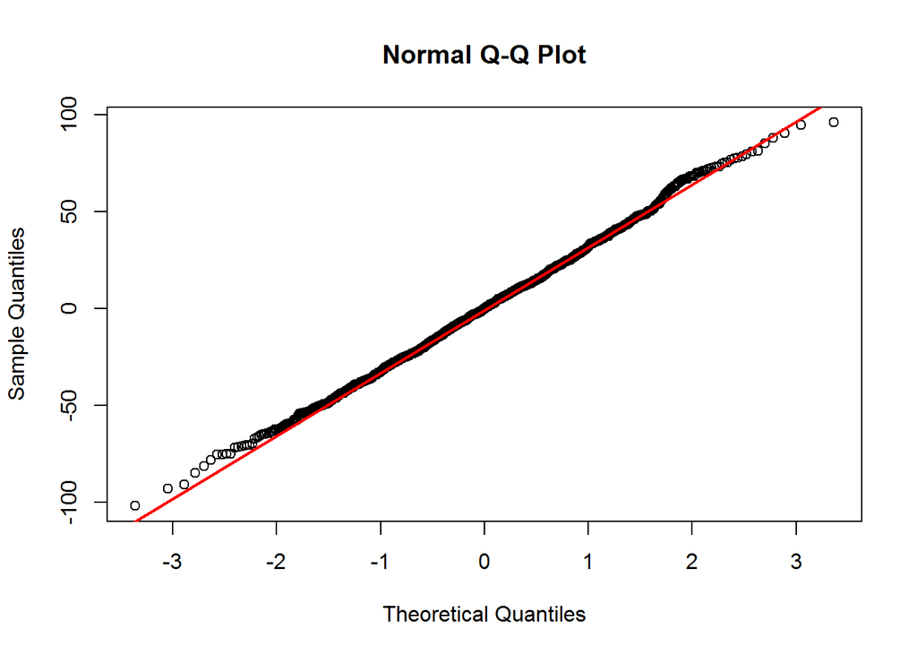

```r
qqnorm(fit_1$resid)
qqline(fit_1$residuals,col='red',lwd=2)
```

- This looks pretty normal (DP’s line up along the Q-Q linewell, with some deviations at the endpoints of the line)

Get closer look at residuals vs fitted values: check for the **assumptions of independence** among the residuals + the **constant variance** assumption. * variance of error terms = constant w/ mean = 0 (centered around horizontal line $y=0$)

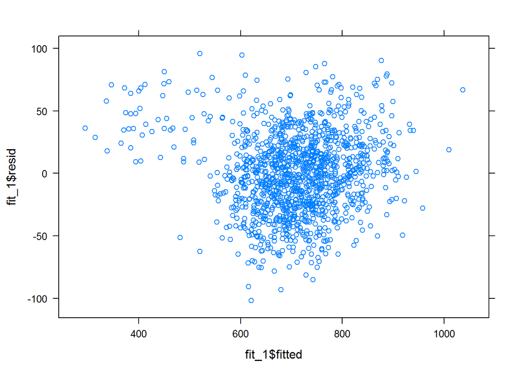

```r
lattice::xyplot(fit_1$resid ~ fit_1$fitted)
```

**4. What do the residual plots suggest about the assumptions of our linear regression model? What about the model makes it possibly a poor fit?** * Multicollinearity could be causing the poor fit, or the true relationship may not be linear * Could predict greater residual values for lower fitted values, as all are > 0

Speaking of residuals, lets take a deeper look at individual predictions: 1970 Braves allowed 185 HR, 478 walks, struck out 960 batters, + gave up 1451 H. Braves = 1st row of our data set.

**5. Calculate how many runs our model predicts that Braves to have scored. What is the residual for the number of runs allowed by the Braves? Did our model overestimate or underestimate Atlanta’s performance?**

```r
braves_y_hat <- -154 + 1.249*(185) + .3605*(478) - .07275*(960) + .3982*(1451)
braves_residual <- teams_1[1,'RA'] - braves_y_hat
paste0('Fitted Braves RA: ',braves_y_hat)
```

```
## [1] "Fitted Braves RA: 757.3322"
```

```r
paste0('True Braves RA: ',teams_1[1,'RA'])
```

```
## [1] "True Braves RA: 772"
```

```r
paste0('Braves Residual (1970): ',braves_residual)
```

```
## [1] "Braves Residual (1970): 14.6677999999999"
```

### R-squared

There are lots of ways to measure the success of a regression model + most common metric = **$R^2$ = fraction of variability in the outcome which is explained by the regression model**

Larger $R^2$ = in principal, better. Using our model, we would interpret $R^2$ as follows: *90% of the variability in RA by a team can be explained by the linear model w/ `HRA`, `BBA`, `SOA`, and `HA`. While popular, traditional $R^2$ = also flawed. Let’s see how. Create 2 new variables, `rand1` + `rand2` = **random normal variables**.

```r
set.seed(0)
teams_1 <- teams_1 %>%
  mutate(rand1 = rnorm(nrow(teams_1)),
         rand2 = rnorm(nrow(teams_1)))

teams_1 %>%
  select(yearID, teamID, rand1, rand2) %>%
  head()
```

```
##   yearID teamID      rand1      rand2
## 1   1970    ATL  1.2629543  0.4894494
## 2   1970    BAL -0.3262334 -0.6728030
## 3   1970    BOS  1.3297993 -2.1674390
## 4   1970    CAL  1.2724293 -0.4491599
## 5   1970    CHA  0.4146414  0.6695928
## 6   1970    CHN -1.5399500 -0.5820698
```

See what happens when we include `rand1` + `rand2` to our regression fit.

```r
fit_2 <- lm(RA ~ HRA + BBA + SOA + HA + rand1 + rand2, teams_1)
msummary(fit_2)
```

```
##               Estimate Std. Error t value Pr(>|t|)
## (Intercept) -1.546e+02  1.136e+01 -13.611   <2e-16 ***
## HRA          1.247e+00  3.455e-02  36.100   <2e-16 ***
## BBA          3.613e-01  1.381e-02  26.151   <2e-16 ***
## SOA         -7.293e-02  5.291e-03 -13.783   <2e-16 ***
## HA           3.983e-01  9.362e-03  42.540   <2e-16 ***
## rand1       -1.100e+00  8.892e-01  -1.237   0.2162
## rand2        1.536e+00  8.748e-01   1.755   0.0794 .
##
## Residual standard error: 31.95 on 1287 degrees of freedom
## Multiple R-squared:  0.8997, Adjusted R-squared:  0.8992
## F-statistic:  1924 on 6 and 1287 DF,  p-value: < 2.2e-16
```

Even w/ added random noise, $R^2$ went up = *not a good thing*, at least when it comes to making model comparisons. *$R^2$ cannot go down*, so $R^2$ = not useful for model comparisons, but more to gain a sense of how much of a drop in the variability in the outcome can be explained by the model’s fit.

In place of $R^2$, R also shows a formula for an **$adjusted R^2$ = penalizes models for adding unneeded parameters (bring in no additional info)**. *However, this metric also has weaknesses*.

#### Akaike information criterion

1 method of *comparing several regression models simultaneously* (as to pick the 1 or 2 best fits) = **Akaike information criterion (AIC) = a function of the model fit + its # of parameters)** = $2k - 2ln(\hat{L})$ where $k$ = # of parameters, $\hat{L}$ = maximum value of the **likelihood function** for the model

- AIC = estimator of the *relative* quality of statistical models for a given set of data.
- Given a collection of models for the data, AIC estimates quality of each, *relative to each of the other models*, providing means for model selection.
- founded on **information theory**: offers an estimate of the relative info lost when a given model is used to represent the process that generated the data. (In doing so, it deals w/ the trade-off betweenmodel goodness of fit + model simplicity)
- AIC does NOT provide a test of a model in the sense of testing a null hypothesis = *tells nothing about the absolute quality of a model, only quality relative to other models, so if ALL candidate models fit poorly, AIC will not give any warning of that*
- Lower AIC = better, as adding useless variables serves only to increase AIC (in general, at least).
- AIC can be easily calculated w/ `AIC()`

```r
AIC(fit_1)
```

```
## [1] 12646.93
```

1 downside of AIC = no natural scale w/ which to make comparisons. However, it’s useful to compare several models at once.

**6. Which model is preferred, and why?**

```r
AIC(fit_1)
```

```
## [1] 12646.93
```

```r
AIC(fit_2)
```

```
## [1] 12646.44
```

- Model 2, compatred to models 1, as its $AIC$ is lower, and its $Adjusted R^2$ is higher